# Bay Wheels Bike Sharing System

## by (Mohammed Khalil)

## Investigation Overview

Bay Wheels is a regional public bicycle sharing system in California's San Francisco Bay Area.

It is operated by Motivate in a partnership with the Metropolitan Transportation Commission and the Bay Area Air Quality Management District. Bay Wheels is 'the first regional and large-scale bicycle sharing system deployed in California and on the West Coast of the United States.

It was established as Bay Area Bike Share in August 2013. As of January 2018, the Bay Wheels system had over 2,600 bicycles in 262 stations across San Francisco, East Bay and San Jose.

In June 2017 the system was officially re-launched as Ford GoBike in a partnership with Ford Motor Company.

After Motivate's acquisition by Lyft, the system was renamed to Bay Wheels in June 2019. The system is expected to expand to 7,000 bicycles around 540 stations in San Francisco, Oakland, Berkeley, Emeryville, and San Jose.

## Dataset Overview

This document explores the Ford GoBike's trip data for public containing bike rides, The attributes included the trip start/end time, as well as additional measurements such as user type, gender and member age.

## Bike Ride Duration (Hours)

#### It's seems that most data are below 1 hour.

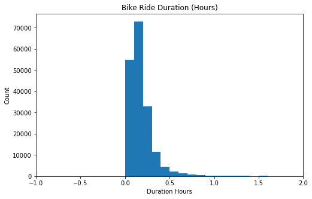

## Weekly usage comparison between customers and subscribers.

#### It seems like subscribers have a more weekly usage compared to customers.

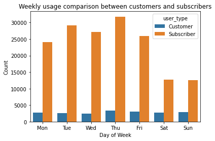

## Avgerage Trip Duration in Hours (Customer/Subscriber)

#### It seems like subscribers ride much shorter trips compared to customers on each day of the week.

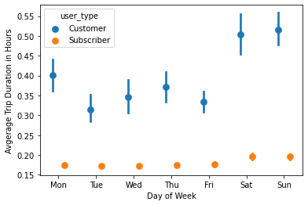